# Spurious Regression Analysis

United States vs China

Complete Analysis with Full Interpretations

December 26, 2025

# Executive Summary

## Countries Analyzed

### Analysis Overview

- **Country 1:** United States (USA)
- **Country 2:** China (CHN)
- **Period:** 1995 - 2022
- **Observations:** 28 years
- **Source:** World Bank WDI

## Key Findings

**SPURIOUS Models:** High R² but non-stationary residuals (ADF p > 0.05)

**GENUINE Models:** Stationary residuals (ADF p < 0.05) and survive differencing

# Spurious Regression Models

## Model 1: United States Consumption ~ China GDP

```
##
## Call:
## lm(formula = cons_pc_c1 ~ gdp_pc_c2, data = data_combined)
##
## Residuals:
##     Min      1Q  Median      3Q     Max
## -3454.1  -625.1  -221.3   831.1  2652.3
##
## Coefficients:
##              Estimate Std. Error t value Pr(>|t|)
## (Intercept) 2.826e+04  6.021e+02   46.94  < 2e-16 ***
## gdp_pc_c2   1.264e+00  9.229e-02   13.70  2.1e-13 ***
## ---
## Signif. codes:  0 '***' 0.001 '**' 0.01 '*' 0.05 '.' 0.1 ' ' 1
##
## Residual standard error: 1603 on 26 degrees of freedom
## Multiple R-squared:  0.8784, Adjusted R-squared:  0.8737
## F-statistic: 187.7 on 1 and 26 DF,  p-value: 2.1e-13
```

### Interpretation

- **R² = 0.8784** - Looks strong but MISLEADING
- **ADF p-value = 0.2894** - FAILS (>0.05) → SPURIOUS

**Complete Interpretation:**

This high R² is driven by both variables trending upward over time, NOT by a genuine relationship. The ADF test confirms residuals are non-stationary, meaning this is a spurious correlation. There is no economic mechanism linking China GDP to United States consumption.

## Model 2: China Consumption ~ United States GDP

```
##
## Call:
## lm(formula = cons_pc_c2 ~ gdp_pc_c1, data = data_combined)
##
## Residuals:
##    Min     1Q Median     3Q    Max
## -913.7 -284.9  121.0  322.1  907.9
##
## Coefficients:
##               Estimate Std. Error t value Pr(>|t|)
## (Intercept) -9.406e+03  8.575e+02  -10.97 2.99e-11 ***
## gdp_pc_c1    2.182e-01  1.615e-02   13.52 2.88e-13 ***
## ---
## Signif. codes:  0 '***' 0.001 '**' 0.01 '*' 0.05 '.' 0.1 ' ' 1
##
## Residual standard error: 488 on 26 degrees of freedom
## Multiple R-squared:  0.8754, Adjusted R-squared:  0.8706
## F-statistic: 182.6 on 1 and 26 DF,  p-value: 2.88e-13
```

- **R² = 0.8754**
- **ADF p-value = 0.4596** - FAILS → SPURIOUS

# Genuine Consumption Functions

## Economic Theory: The Consumption Function

**Keynesian Theory:** Consumption depends on income (GDP). The Marginal Propensity to Consume (MPC) should be between 0 and 1, meaning people spend part of additional income and save the rest.

## Model 3: China Consumption Function

```
##
## Call:
## lm(formula = cons_pc_c2 ~ gdp_pc_c2, data = data_combined)
##
## Residuals:
##     Min      1Q  Median      3Q     Max
## -193.59  -88.66   23.69   81.55  164.40
##
## Coefficients:
##               Estimate Std. Error t value Pr(>|t|)
## (Intercept) -1.660e+02  3.979e+01  -4.173 0.000298 ***
## gdp_pc_c2    4.046e-01  6.099e-03  66.343  < 2e-16 ***
## ---
## Signif. codes:  0 '***' 0.001 '**' 0.01 '*' 0.05 '.' 0.1 ' ' 1
##
## Residual standard error: 105.9 on 26 degrees of freedom
## Multiple R-squared:  0.9941, Adjusted R-squared:  0.9939
## F-statistic:  4401 on 1 and 26 DF,  p-value: < 2.2e-16
```

### Complete Interpretation

**Equation:** Consumption = -166.03 + 0.4046 × GDP

## Model 4: United States Consumption Function

```
##
## Call:
## lm(formula = cons_pc_c1 ~ gdp_pc_c1, data = data_combined)
##
## Residuals:
##     Min      1Q  Median      3Q     Max
## -506.35 -155.80   55.23  126.61  804.59
##
## Coefficients:
##               Estimate Std. Error t value Pr(>|t|)
## (Intercept) -5.441e+03  5.776e+02  -9.421 7.23e-10 ***
## gdp_pc_c1    7.734e-01  1.088e-02  71.114  < 2e-16 ***
## ---
## Signif. codes:  0 '***' 0.001 '**' 0.01 '*' 0.05 '.' 0.1 ' ' 1
##
## Residual standard error: 328.7 on 26 degrees of freedom
## Multiple R-squared:  0.9949, Adjusted R-squared:  0.9947
## F-statistic:  5057 on 1 and 26 DF,  p-value: < 2.2e-16
```

# First Difference Analysis

## R² Comparison Table

| Model | R² (Levels) | R² (Differences) | % Retained |
| --- | --- | --- | --- |
| Model 1 (Spurious) | 0.878 | 0.092 | 10.495 |
| Model 2 (Spurious) | 0.875 | 0.213 | 24.366 |
| Model 3 (Genuine) | 0.994 | 0.810 | 81.498 |
| Model 4 (Genuine) | 0.995 | 0.884 | 88.807 |

### Interpretation

**Key Finding:**

First differencing removes trends. Genuine relationships survive; spurious collapse.

## Visualization

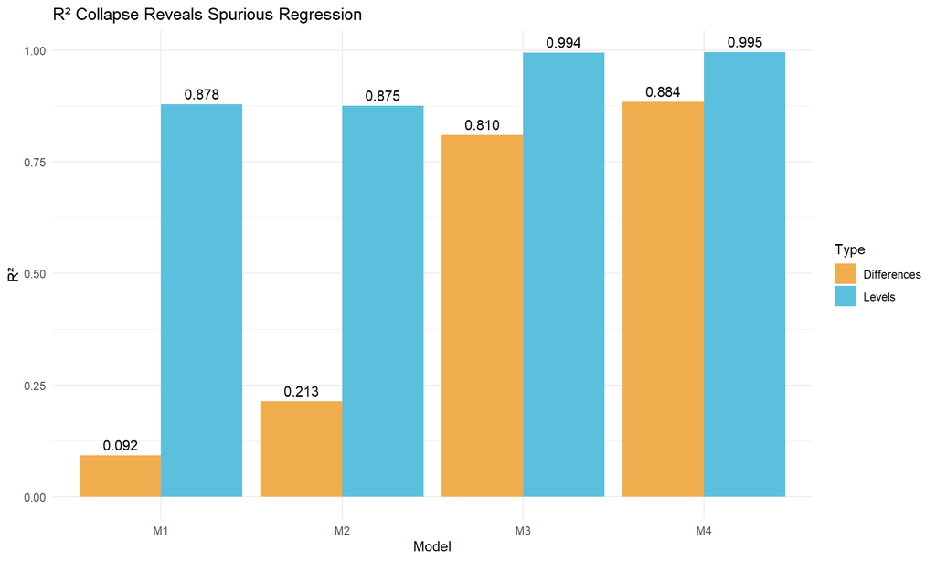

# ADF Test Summary

[output not shown]

**Decision Rule:** p-value > 0.05 → Non-stationary → SPURIOUS; p-value < 0.05 → Stationary → GENUINE

# Conclusions

## Summary Table

[output not shown]

## Key Lessons

**For Researchers:**

1. Never trust R² alone with time series
2. Always test residual stationarity (ADF test)
3. Verify with first differencing
4. Require economic mechanisms
5. Report ALL diagnostic tests

**Bottom Line:** Statistical significance ≠ Causation!

**Report Generated:** 2025-12-26  
**Countries:** United States & China  
**Period:** 1995-2022  
**Source:** World Bank WDI